## Connect With Us

- Website (https://www.rsquaredacademy.com/)
- Free Online R Courses (https://rsquared-academy.thinkific.com/)
- R Packages (https://pkgs.rsquaredacademy.com)
- Shiny Apps (https://apps.rsquaredacademy.com)
- Blog (https://blog.rsquaredacademy.com)
- GitHub (https://github.com/rsquaredacademy)
- YouTube (https://www.youtube.com/user/rsquaredin/)
- Twitter (https://twitter.com/rsquaredacademy)
- Facebook (https://www.facebook.com/rsquaredacademy/)
- Linkedin (https://in.linkedin.com/company/rsquared-academy)
- What?
- Why?
- How?
- Use Cases
- Demo

## What?

- unsupervised data mining technique
- employed by retailers to understand purchase behaviors
- used to determine what items are frequently bought together
- it creates **IF-THEN** scenario rules

## Why ?

- store layout
- online recommendation engines
- targeted marketing campaigns
- cross-selling
- up-selling
- catalogue design
- enhance customer experience

## Advantages

- cost-effective
- insightful
- flexible
- actionable

## Use Cases

- retail
- telecommunications
- banks
- insurance
- medical
- manufacturing

## Steps

- frequent itemset generation
- rules generation

## Simple Example

## Itemset

## Antecedent

## Consequent

## Support

## Confidence

## Lift

## Data

- [UCI](http://archive.ics.uci.edu/ml/datasets/online+retail#)
- [data.world](https://data.world/datasets/market-basket-analysis)

## Data Dictionary

- invoice number
- description
- quantity
- invoice date
- unit price
- customer id
- country

## Libraries

```r
library(readxl)
library(readr)
library(mbar)
library(arules)
library(arulesViz)
library(magrittr)
```

## Preprocessing

```r
mba_data     <- read_excel("online-retail.xlsx")
transactions <- mbar_prep_data(mba_data, InvoiceNo, Description)
head(transactions)
```

```
## # A tibble: 6 x 1,114
##   item_1 item_2 item_3 item_4 item_5 item_6 item_7 item_8 item_9 item_10
##   <chr>  <chr>  <chr>  <chr>  <chr>  <chr>  <chr>  <chr>  <chr>  <chr>
## 1 BATH ~ ""     ""     ""     ""     ""     ""     ""     ""     ""
## 2 PAPER~ ""     ""     ""     ""     ""     ""     ""     ""     ""
## 3 VICTO~ ""     ""     ""     ""     ""     ""     ""     ""     ""
## 4 JAM M~ ""     ""     ""     ""     ""     ""     ""     ""     ""
## 5 Disco~ ""     ""     ""     ""     ""     ""     ""     ""     ""
## 6 SET O~ ""     ""     ""     ""     ""     ""     ""     ""     ""
## # ... with 1,104 more variables: item_11 <chr>, item_12 <chr>,
## #   item_13 <chr>, item_14 <chr>, item_15 <chr>, item_16 <chr>,
## #   item_17 <chr>, item_18 <chr>, item_19 <chr>, item_20 <chr>,
## #   item_21 <chr>, item_22 <chr>, item_23 <chr>, item_24 <chr>,
## #   item_25 <chr>, item_26 <chr>, item_27 <chr>, item_28 <chr>,
## #   item_29 <chr>, item_30 <chr>, item_31 <chr>, item_32 <chr>,
## #   item_33 <chr>, item_34 <chr>, item_35 <chr>, item_36 <chr>,
## #   item_37 <chr>, item_38 <chr>, item_39 <chr>, item_40 <chr>,
## #   item_41 <chr>, item_42 <chr>, item_43 <chr>, item_44 <chr>,
## #   item_45 <chr>, item_46 <chr>, item_47 <chr>, item_48 <chr>,
## #   item_49 <chr>, item_50 <chr>, item_51 <chr>, item_52 <chr>,
## #   item_53 <chr>, item_54 <chr>, item_55 <chr>, item_56 <chr>,
## #   item_57 <chr>, item_58 <chr>, item_59 <chr>, item_60 <chr>,
## #   item_61 <chr>, item_62 <chr>, item_63 <chr>, item_64 <chr>,
## #   item_65 <chr>, item_66 <chr>, item_67 <chr>, item_68 <chr>,
## #   item_69 <chr>, item_70 <chr>, item_71 <chr>, item_72 <chr>,
## #   item_73 <chr>, item_74 <chr>, item_75 <chr>, item_76 <chr>,
## #   item_77 <chr>, item_78 <chr>, item_79 <chr>, item_80 <chr>,
## #   item_81 <chr>, item_82 <chr>, item_83 <chr>, item_84 <chr>,
## #   item_85 <chr>, item_86 <chr>, item_87 <chr>, item_88 <chr>,
## #   item_89 <chr>, item_90 <chr>, item_91 <chr>, item_92 <chr>,
## #   item_93 <chr>, item_94 <chr>, item_95 <chr>, item_96 <chr>,
## #   item_97 <chr>, item_98 <chr>, item_99 <chr>, item_100 <chr>,
## #   item_101 <chr>, item_102 <chr>, item_103 <chr>, item_104 <chr>,
## #   item_105 <chr>, item_106 <chr>, item_107 <chr>, item_108 <chr>,
## #   item_109 <chr>, item_110 <chr>, ...
```

## Exploratory Data Analysis

## Read Data

```r
basket_data <- read.transactions("transaction_data.csv", format = "basket",
  sep = ",")
basket_data
```

```
## transactions in sparse format with
##  25901 transactions (rows) and
##  10085 items (columns)
```

## Summary

```r
summary(basket_data)
```

```
## transactions as itemMatrix in sparse format with
##  25901 rows (elements/itemsets/transactions) and
##  10085 columns (items) and a density of 0.001660018
##
## most frequent items:
## WHITE HANGING HEART T-LIGHT HOLDER           REGENCY CAKESTAND 3 TIER
##                               1999                               1914
##            JUMBO BAG RED RETROSPOT                      PARTY BUNTING
##                               1806                               1488
##            LUNCH BAG RED RETROSPOT                            (Other)
##                               1404                             425005
##
## element (itemset/transaction) length distribution:
## sizes
##    0    1    2    3    4    5    6    7    8    9   10   11   12   13   14
```

[output cut: 46 more lines]

## Item Frequency Plot

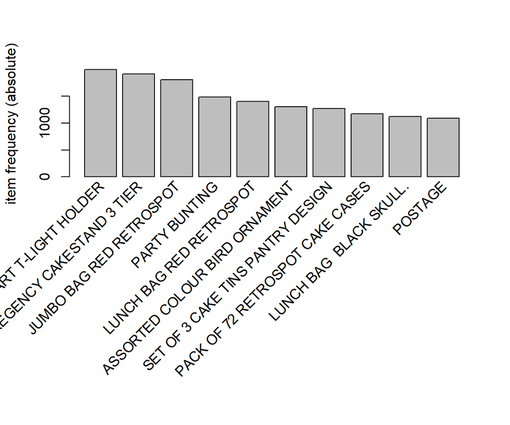

```r
itemFrequencyPlot(basket_data, topN = 10, type = 'absolute')
```

## Generate Rules

```r
rules <- apriori(basket_data, parameter = list(supp=0.009, conf=0.8,
    target = "rules", maxlen = 4))
```

```
## Apriori
##
## Parameter specification:
##  confidence minval smax arem  aval originalSupport maxtime support minlen
##         0.8    0.1    1 none FALSE            TRUE       5   0.009      1
##  maxlen target   ext
##       4  rules FALSE
##
## Algorithmic control:
##  filter tree heap memopt load sort verbose
##     0.1 TRUE TRUE  FALSE TRUE    2    TRUE
##
## Absolute minimum support count: 233
##
## set item appearances ...[0 item(s)] done [0.00s].
## set transactions ...[10085 item(s), 25901 transaction(s)] done [1.78s].
## sorting and recoding items ... [508 item(s)] done [0.03s].
## creating transaction tree ... done [0.10s].
## checking subsets of size 1 2 3 4
```

```
##  done [0.11s].
## writing ... [22 rule(s)] done [0.00s].
## creating S4 object  ... done [0.05s].
```

## Rules Summary

```r
summary(rules)
```

```
## set of 22 rules
##
## rule length distribution (lhs + rhs):sizes
##  2  3  4
## 11  9  2
##
##    Min. 1st Qu.  Median    Mean 3rd Qu.    Max.
##   2.000   2.000   2.500   2.591   3.000   4.000
##
## summary of quality measures:
##     support           confidence          lift           count
##  Min.   :0.009034   Min.   :0.8035   Min.   :22.59   Min.   :234.0
##  1st Qu.:0.010453   1st Qu.:0.8530   1st Qu.:25.02   1st Qu.:270.8
##  Median :0.013223   Median :0.8868   Median :55.94   Median :342.5
##  Mean   :0.012760   Mean   :0.9120   Mean   :48.55   Mean   :330.5
##  3rd Qu.:0.014362   3rd Qu.:1.0000   3rd Qu.:61.23   3rd Qu.:372.0
##  Max.   :0.018339   Max.   :1.0000   Max.   :71.30   Max.   :475.0
##
## mining info:
##         data ntransactions support confidence
##  basket_data         25901   0.009        0.8
```

## Inspect Rules

```r
basket_rules <- sort(rules, by = 'confidence', decreasing = TRUE)
inspect(basket_rules[1:10])
```

```
##      lhs                                  rhs                                   support confidence     lift count
## [1]  {BACK DOOR}                       => {KEY FOB}                         0.009613528  1.0000000 61.23168   249
## [2]  {SET 3 RETROSPOT TEA}             => {SUGAR}                           0.014362380  1.0000000 69.62634   372
## [3]  {SUGAR}                           => {SET 3 RETROSPOT TEA}             0.014362380  1.0000000 69.62634   372
## [4]  {SET 3 RETROSPOT TEA}             => {COFFEE}                          0.014362380  1.0000000 55.94168   372
## [5]  {SUGAR}                           => {COFFEE}                          0.014362380  1.0000000 55.94168   372
## [6]  {SHED}                            => {KEY FOB}                         0.011273696  1.0000000 61.23168   292
## [7]  {SET 3 RETROSPOT TEA,
##       SUGAR}                           => {COFFEE}                          0.014362380  1.0000000 55.94168   372
## [8]  {COFFEE,
##       SET 3 RETROSPOT TEA}             => {SUGAR}                           0.014362380  1.0000000 69.62634   372
## [9]  {COFFEE,
##       SUGAR}                           => {SET 3 RETROSPOT TEA}             0.014362380  1.0000000 69.62634   372
## [10] {PINK REGENCY TEACUP AND SAUCER,
##       REGENCY CAKESTAND 3 TIER,
##       ROSES REGENCY TEACUP AND SAUCER} => {GREEN REGENCY TEACUP AND SAUCER} 0.009999614  0.8900344 25.16679   259
```

## Redundant Rules

```r
rules_redundant <-
  basket_rules %>%
  is.subset(rules) %>%
  colSums() %>%
  is_greater_than(1) %>%
  which()
```

## Redundant Rules

```r
rules_redundant
```

```
##                                                                                               {SET 3 RETROSPOT TEA,SUGAR}
##                                                                                                                         3
##                                                                                               {SET 3 RETROSPOT TEA,SUGAR}
##                                                                                                                         4
##                                                                                              {COFFEE,SET 3 RETROSPOT TEA}
##                                                                                                                         5
##                                                                                              {COFFEE,SET 3 RETROSPOT TEA}
##                                                                                                                         6
##                                                                                                            {COFFEE,SUGAR}
##                                                                                                                         7
##                                                                                                            {COFFEE,SUGAR}
##                                                                                                                         8
##                                                                                        {COFFEE,SET 3 RETROSPOT TEA,SUGAR}
##                                                                                                                        12
##                                                                                        {COFFEE,SET 3 RETROSPOT TEA,SUGAR}
##                                                                                                                        13
##                                                                                        {COFFEE,SET 3 RETROSPOT TEA,SUGAR}
##                                                                                                                        14
##                            {SET/20 RED RETROSPOT PAPER NAPKINS,SET/6 RED SPOTTY PAPER CUPS,SET/6 RED SPOTTY PAPER PLATES}
##                                                                                                                        15
##                          {GREEN REGENCY TEACUP AND SAUCER,PINK REGENCY TEACUP AND SAUCER,ROSES REGENCY TEACUP AND SAUCER}
##                                                                                                                        16
##                          {GREEN REGENCY TEACUP AND SAUCER,PINK REGENCY TEACUP AND SAUCER,ROSES REGENCY TEACUP AND SAUCER}
##                                                                                                                        17
## {GREEN REGENCY TEACUP AND SAUCER,PINK REGENCY TEACUP AND SAUCER,REGENCY CAKESTAND 3 TIER,ROSES REGENCY TEACUP AND SAUCER}
##                                                                                                                        21
## {GREEN REGENCY TEACUP AND SAUCER,PINK REGENCY TEACUP AND SAUCER,REGENCY CAKESTAND 3 TIER,ROSES REGENCY TEACUP AND SAUCER}
##                                                                                                                        22
```

## Remove Redundant Rules

```r
rules_pruned <- basket_rules[-rules_redundant]
inspect(rules_pruned)
```

```
##     lhs                                     rhs                                   support confidence     lift count
## [1] {BACK DOOR}                          => {KEY FOB}                         0.009613528  1.0000000 61.23168   249
## [2] {SET 3 RETROSPOT TEA}                => {SUGAR}                           0.014362380  1.0000000 69.62634   372
## [3] {COFFEE,
##      SUGAR}                              => {SET 3 RETROSPOT TEA}             0.014362380  1.0000000 69.62634   372
## [4] {PINK REGENCY TEACUP AND SAUCER,
##      REGENCY CAKESTAND 3 TIER,
##      ROSES REGENCY TEACUP AND SAUCER}    => {GREEN REGENCY TEACUP AND SAUCER} 0.009999614  0.8900344 25.16679   259
## [5] {SET/20 RED RETROSPOT PAPER NAPKINS,
##      SET/6 RED SPOTTY PAPER CUPS}        => {SET/6 RED SPOTTY PAPER PLATES}   0.009111617  0.8872180 48.68609   236
## [6] {REGENCY TEA PLATE GREEN}            => {REGENCY TEA PLATE ROSES}         0.010347091  0.8322981 55.99313   268
## [7] {STRAWBERRY CHARLOTTE BAG,
##      WOODLAND CHARLOTTE BAG}             => {RED RETROSPOT CHARLOTTE BAG}     0.010771785  0.8110465 23.65644   279
## [8] {SET/6 RED SPOTTY PAPER CUPS}        => {SET/6 RED SPOTTY PAPER PLATES}   0.012084476  0.8087855 44.38211   313
```

## What influenced purchase of product X?

```r
sugar_rules <- apriori(basket_data, parameter = list(supp = 0.009, conf = 0.8),
  appearance = list(default = "lhs", rhs = "SUGAR"), control = list(verbose = F))
rules_sugar <- sort(sugar_rules, by = "confidence", decreasing = TRUE)
inspect(rules_sugar)
```

```
##     lhs                             rhs     support    confidence lift
## [1] {SET 3 RETROSPOT TEA}        => {SUGAR} 0.01436238 1.0000000  69.62634
## [2] {COFFEE,SET 3 RETROSPOT TEA} => {SUGAR} 0.01436238 1.0000000  69.62634
## [3] {COFFEE}                     => {SUGAR} 0.01436238 0.8034557  55.94168
##     count
## [1] 372
## [2] 372
## [3] 372
```

## What purchases did product X influence?

```r
sugar_rules <- apriori(basket_data, parameter = list(supp = 0.009, conf = 0.8),
  appearance = list(default = "rhs", lhs = "SUGAR"), control = list(verbose = F))
rules_sugar <- sort(sugar_rules, by = "confidence", decreasing = TRUE)
inspect(rules_sugar)
```

```
##     lhs        rhs                   support    confidence lift     count
## [1] {SUGAR} => {SET 3 RETROSPOT TEA} 0.01436238 1          69.62634 372
## [2] {SUGAR} => {COFFEE}              0.01436238 1          55.94168 372
```

## Top Rules

```r
top_rules <- basket_rules[1:10]
inspect(top_rules)
```

```
##      lhs                                  rhs                                   support confidence     lift count
## [1]  {BACK DOOR}                       => {KEY FOB}                         0.009613528  1.0000000 61.23168   249
## [2]  {SET 3 RETROSPOT TEA}             => {SUGAR}                           0.014362380  1.0000000 69.62634   372
## [3]  {SUGAR}                           => {SET 3 RETROSPOT TEA}             0.014362380  1.0000000 69.62634   372
## [4]  {SET 3 RETROSPOT TEA}             => {COFFEE}                          0.014362380  1.0000000 55.94168   372
## [5]  {SUGAR}                           => {COFFEE}                          0.014362380  1.0000000 55.94168   372
## [6]  {SHED}                            => {KEY FOB}                         0.011273696  1.0000000 61.23168   292
## [7]  {SET 3 RETROSPOT TEA,
##       SUGAR}                           => {COFFEE}                          0.014362380  1.0000000 55.94168   372
## [8]  {COFFEE,
##       SET 3 RETROSPOT TEA}             => {SUGAR}                           0.014362380  1.0000000 69.62634   372
## [9]  {COFFEE,
##       SUGAR}                           => {SET 3 RETROSPOT TEA}             0.014362380  1.0000000 69.62634   372
## [10] {PINK REGENCY TEACUP AND SAUCER,
##       REGENCY CAKESTAND 3 TIER,
##       ROSES REGENCY TEACUP AND SAUCER} => {GREEN REGENCY TEACUP AND SAUCER} 0.009999614  0.8900344 25.16679   259
```

## Scatter Plot

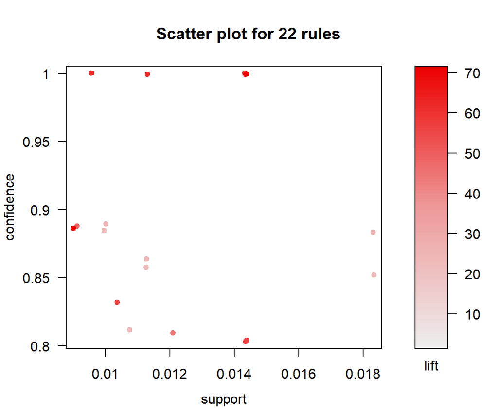

```r
plot(basket_rules)
```

## Network Plot

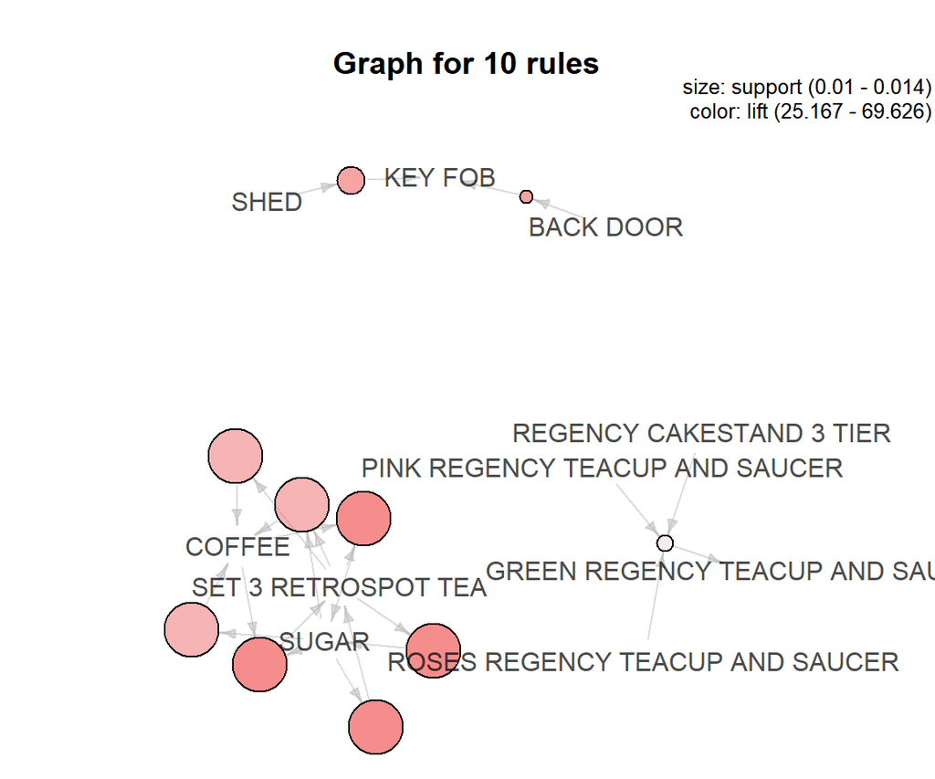

```r
plot(top_rules, method = 'graph')
```

## Summary

**WHAT**

unsupervised data mining technique employed by retailers to understand purchase behaviors and used to determine what items are frequently bought together

**WHY**

store layout, online recommendation engines, targeted marketing campaigns, cross-selling, up-selling, catalogue design, enhance customer experience etc

**ADVANTAGES**

cost-effective, insightful, flexible and actionable

**USAGE**

retail, telecommunications, banks, insurance, medical, manufacturing

**WARNING**

- directionality of rule is lost while using **lift**
- **confidence** as a measure can be misleading